# Titel Thesen Temperamente - Die Themen der Sozialen Passagen

## Topic Modeling

In den letzten Jahren wurde das Topic Modeling als Methode für die quantitative Analyse von Texten vor allem in den Digital Humanities häufig diskutiert und in vielen Studien angewandt (vgl. McFarland et al. 2013). Unter Topic Modeling werden zumeist Methoden verstanden, die auch als ‘Generative Models’ bezeichnet werden, da sie unter Zuhilfenahme von probabilistischen Verfahren die Konstruktion eines Textes nachbilden (vgl. Steyvers & Griffiths 2007). Ziel solcher Methoden ist es, latente semantische Strukturen in den Texten zu ermitteln und dadurch Themen zu extrahieren. Sie eignen sich vor allem für die Analyse sehr großer Textdatenmengen, deren Inhalte bisweilen nur wenig bekannt oder deren Daten noch durch ihre Unstrukturiertheit und durch fehlende Metadaten gekennzeichnet sind. Neben der Latent Semantic Analysis (LSA) von Deerwester et al. (1990) ist wohl die Latent Dirichlet Allocation (LDA) von [Blei et al. (2003)](http://www.jmlr.org/papers/volume3/blei03a/blei03a.pdf) die bekannteste Methode des Topic Modelings.

Zweitere soll in dieser Studie zum Einsatz kommen. Die LDA zeichnet sich dadurch aus, dass eben kein Forscher*in Themen subjektiv vorgeben muss, z. B. in Form von Schlüsselworten, deren Häufigkeit in einem Text ermittelt werden. Bei der LDA können Themen auf Grundlage von gemeinsam auftretenden Wörtern in den Dokumenten mithilfe eines komplexen probabilistischen Modells gefunden werden. Für die Analyse der Daten kam das R Package [Structural Topic Modeling (STM)](https://www.structuraltopicmodel.com/) zum Einsatz. Das STM ist eine Erweiterung des LDA, da in diesem Modell Metadaten, wie zum Beispliel das Erscheiungungsdatum eines Textes mit berücksichtigt wird.

```r
#R Packages
library(magrittr)
library(dplyr)
library(quanteda)
library(spacyr)
library(stm)
library(DT)
library(sna)
library(ggplot2)
```

## Corpus

Um die Artikel mithilfe Methoden der quantiativen Textanalyse untersuchen zu können braucht es eine bestimmte Datenaufbereitung und -struktur des Textes. Zunächst wurde dabei die Artikel in einzelne Sequenzen zerteilt, da für eine LDA es nicht sinnvoll ist, mit sehr langen Dokumenten zu arbeiten. Daher wurden die einzelnen Artikel anhang ihrer eigenen Absatzstruktur geteilt. Insgesamt entstanden dadurch *8995* Dokumente, die für die Analyse herangezogen wurden.

```r
df.t <- df2[!duplicated(df2$Artikel), ]
summary(df.t)
```

## Textbereinigung

### POS-Tagging & Lemmatising

Der erste Schritt ist das *Tokenizing*. Darunter versteht man einen Prozess, in dem der Text in untersuchbare Einheiten zerlegt wird. Ein Token kann entweder aus einem Satz, aus mehreren Wörtern oder aus einzelnen Wörtern bestehen. Zweitens wurde eine Lemmatisierung durchgeführt. Lemmatisierung ist ein wichtiger Schritt für die Analyse, da damit die Beugungen eines Wortes auf ihre Grundform reduziert wird. So wird Beispielsweise aus *traf*, *treffe*, *trift* und *treffen* auf die Form *treffen* zurückgeführt. Die Rückführung der Wörter auf ihren Wortstamm wird in der Computerlinguistik als sinnvoll angesehen, weil bei dem reinen Zählen der Wörter in einem Corpus ein Wort dadurch weniger Varianz aufweist. Diese Informationsreduktion führt dabei auch zu besseren Analyseergebnissen, ohne zu stark in den Sinngehalt der Wörter einzugreifen. Für die Lemmatisierung muss in einem Schritt davor die syntaktische Funktion der Wörter in einem Satz bestimmt werden. Hierfür wurde ein sogenanntes [POS-Tagging](https://de.wikipedia.org/wiki/Part-of-speech-Tagging) angewandt, dessen Datengrundlage eben einzelne Wörter sind, wobei die Satzstruktur noch erhalten sein muss. Für das Tokenizing, das POS-Tagging und die Lemmatisierung wurde die [spaCy](https://spacy.io/) Bibliothek verwendet.

```r
# Start the clock!
ptm <- proc.time()

spacy_initialize(model = 'de' ,refresh_settings = TRUE)
parsed <- spacy_parse(df2$Zitat)
spacy_finalize()
save.image('output/data/sp_text_paresed.RData')

proc.time() - ptm
```

### Document Term Matrix

In einem darauffolgenden Schritt wurden die Tokens als [Bag of words](https://en.wikipedia.org/wiki/Bag-of-words_model) abgespeichert. Darunter ist eine vereinfachte Darstellung von Text im [Natural language processing (NLP)](https://en.wikipedia.org/wiki/Natural_language_processing) gemeint, in der jedes Wort nur noch einmal pro Dokument und mir ihrer jeweiligen Auftretenshäufigkeit abgespeichert wird.

Danach wurden Punktionen, Leerzeichen und Kommata, sowie *stop-words* gelöscht. Letztere sind Wörter, die keinen relevanten Informationswert für die Themenbestimmung besitzen. Deutsche *stop-words* sind zum Beispiel *und*, *durch*, *von* oder *aber*. Da der Computer ein und dasselbe Wort aufgrund der Groß- und Kleinschreibung als unterschiedliche Wörter auffassen würde, wurden alle Wörter klein geschrieben. Zudem wurden in diesem Schritt auch *bi-grams* erzeugt. Dies sind häufig gemeinsam auftretende Wörter, die eine semantische Bedeutung besitzen, wie zum Beispiel *Soziale Arbeit*.

Die Ausgangslage für unterschiedlichen quantitativen Analysen von Texten ist die [Dokument Term Matrix (DTM)](https://en.wikipedia.org/wiki/Document-term_matrix). Der Index der Zeilen der DTM werden durch die jeweiligen Dokumente repräsentiert. Die Spalten beinhalten die Wörter, die im Corpus auftreten und nicht durch die Textbereinigung entfernt wurden. In den jeweiligen Zellen steht die Häufigkeit des Auftretens eines Wortes in einem Dokument. Durch diese Datenstruktur werden die Texte als Summe ihrer Wörter aufgefasst, sprich die grammatikalische Struktur selbst geht zwar verloren, jedoch können dadurch unterschiedlichste frequenzielle, und in unserem Fall probabilistische Analysen durchgeführt werden.

```r
load('output/data/sp_text_paresed.RData') # loads lemma

tokens <- as.tokens(parsed, use_lemma = TRUE) %>%
  tokens(remove_punct = TRUE, remove_numbers = TRUE) %>%
  tokens_tolower() %>%
  tokens_remove(c(stopwords('de'), "vgl", "et_a1", "fiir","v0n", "a1s", "hinsichtlich",
                  "11nd", "z._b.", "cine", "hierzu", "erstens", "zweitens", "deutlich", "tion",
                   "geben", "mehr", "immer", "schon", "gehen", "sowie", "erst", "mehr", "etwa",
                  "dabei", "dis-", "beziehungsweise", "seit", "drei", "insbesondere",
                  stopwords("en")),
                min_nchar = 4L,  padding = TRUE)


collocation <- textstat_collocations(tokens, min_count = 30)
tokens <- tokens_compound(tokens, collocation, join = FALSE)


docvars(tokens) <- df2 %>% select(Artikel, Zitat, Jahr) %>% rename(text = 'Zitat')


dfm_sp <- tokens %>% dfm() %>% dfm_select(min_nchar = 4L) %>%
  dfm_trim(min_docfreq = 50) %>%  # minimum 50 documents (removes rare terms)
   dfm_trim(max_docfreq = 0.25,
            docfreq_type = 'prop') # maximum in 25 percent of documents (stop words)

sp_grouped <- dfm_group(dfm_sp, groups = 'Jahr') # grouped dfm for keyness
```

## STM Model

```r
#Evaluation
```

Im Folgenden gilt es die Ergebnisse dieses Modells näher darzulegen. Für die Berechnung der Modelle wurden nicht alle Wörter des Corpus mit aufgenommen, sondern nur die 10.000 häufigsten. Aus vorherigen Analysen mit allen Wörtern ergab sich bei gleicher Topicanzahl sehr ähnliche Topics, von daher geht dieser reduzierter Corpus nicht auf Kosten des Modells. Der Vorteil liegt darin, dass das Modell um eine vielfaches schneller berechnet wurde.

## Score

| X1 | X2 | X3 | X4 | X5 | X6 | X7 | X8 | X9 | X10 | X11 | X12 | X13 | X14 | X15 | X16 | X17 | X18 | X19 | X20 |
| --- | --- | --- | --- | --- | --- | --- | --- | --- | --- | --- | --- | --- | --- | --- | --- | --- | --- | --- | --- |
| facebook | kind | familie | jugendliche | well | education | work | care | sozial_arbeit | lesen | social_work | jugend | anerkennung | management | development | entfremdung | mutter | social | schﬁtzen | mensch |
| insti- | child | family | jugendhilfe | hochschule | national | studie | organisation | soziale_arbeit | professionell | system | gesellschaft | relation | korper | analyse | gruppe | frau | article | strafen | gott |
| beziehung | eltern | baum | bmfsfj | wissenschaft | international | befragung | einrichtung | sozialer_arbeit | bourdieu | profession | agenda | honneth | ordnung | evaluation | befragte | tochter | research | klient | kirche |
| kﬁnnen | kindheit | unterstﬁtzung | kinder- | projekt | children | untersuchung | akteur | fundamental | praktik | sozialarbeit | politisch | scham | foucault | normativ | hoch | interview | abstract | therapie | religion |
| medium | erwachsene | fﬁrsorge | inklusion | disziplin | deutschland | ergebnis | christlich | kritik | reckwitz | luhmann | gesellschaftlich | freiheit | kﬁrper | programm | gering | sagen | professional | padagogischen | religiésen |
| internet | gewalt | elternschaft | kinder— | wissenschaftlich | reform | interview | glaubensgemeinschaften | otto | praxis | maurer | politik | paternalismus | gewalt | relevant | berufen | vater | welfare | klientinnen | kirchlich |
| million | sexuell | familiale | behinderung | promotion | capability | verfahren | caritas | sozialpolitisch | feld | deﬁnition | politische | person | subjekt | modell | eher | essen | practice | mﬁssen | muslim |
| nutzen | recht | armut | jugendarbeit | soziologie | europa | sexuell_gewalt | regional | adressat*innen | sozialpadagogik | integration | hornstein | autonomie | grenzen | basis | klasse | herr | keywords | konnen | welt |
| sozial_beziehung | kindlich | hilfe | inklusiven | sport | global | qualitativ | gemeinde | sozialstaat | forschende | expertise | generation | vernunft | norm | text | person | madchen | people | padagogik | leben |
| droge | menschenrechte | fami- | viii | studierende | lokal | auswertung | kooperation | peter | lebensformen | kernen | jahrhundert | nussbaum | grenze | pro- | belastung | gesprach | different | schﬁler | islam |

## FREX

| X1 | X2 | X3 | X4 | X5 | X6 | X7 | X8 | X9 | X10 | X11 | X12 | X13 | X14 | X15 | X16 | X17 | X18 | X19 | X20 |
| --- | --- | --- | --- | --- | --- | --- | --- | --- | --- | --- | --- | --- | --- | --- | --- | --- | --- | --- | --- |
| beziehung | kind | familie | jugendhilfe | hochschule | international | studie | organisation | sozialer_arbeit | feld | sozialarbeit | jugend | anerkennung | ordnung | analyse | gruppe | mutter | social | beratung | mensch |
| medium | kindheit | baum | inklusion | projekt | national | verfahren | care | soziale_arbeit | professionell | social_work | politische | scham | grenze | relevant | gering | frau | research | mﬁssen | religion |
| nutzen | child | unterstﬁtzung | kinder- | wissenschaft | europa | ergebnis | akteur | sozial_arbeit | bourdieu | profession | politisch | honneth | korper | strategie | hoch | sagen | abstract | klient | welt |
| kﬁnnen | erwachsene | fﬁrsorge | kinder— | disziplin | global | untersuchung | einrichtung | otto | professionelle | system | politik | individuum | markieren | programm | eher | essen | keywords | ware | kirchlich |
| facebook | eltern | armut | jugendliche | wissenschaftlich | education | untersuchen | region | kritik | wissen | deﬁnition | gesellschaft | autonomie | grenzen | text | befragte | szene | moral | dafﬁr | religiésen |
| mﬁglichkeit | kindlich | ressource | behinderung | soziologie | reform | qualitativ | professionen | sozialpolitik | praxis | luhmann | generation | paternalismus | norm | evaluation | relativ | beim | welfare | padagogische | gott |
| internet | menschenrechte | family | jugendarbeit | sport | capability | instrument | gemeinde | sozialpolitisch | theoretisch | expertise | gesellschaftliche | ungleichheit | diskurs | modell | berufen | bekommen | article | vertrauen | muslim |
| sozial_beziehung | sexuell | orten | jung_mensch | wissenschaftliche | lokal | datum | setting | peter | uberlegungen | kernen | jahrhundert | freiheit | kﬁrper | ansatz | unterschied | interview | migration | behandlung | bewusstsein |
| nutzer | kinderschutz | bildungsprozesse | schulen | studierende | children | befragung | regional | ziegler | praktik | maurer | gesellschaftlich | moralisch | foucault | ausgehen_dass | klasse | vater | professional | seite | kirche |
| wichtig | sexuelle | elternschaft | viii | phase | deutschland | befund | institution | aktivierend | forschende | integration | bewegung | eingriff | sinnen | davon_ausgehen | belastung | madchen | people | padagogik | islam |

## Topics Analyse

ighest Prob: are the words within each topic with the highest probability (inferred directly from topic-word distribution parameter β).

FREX: are the words that are both frequent and exclusive, identifying words that distinguish topics. This is calculated by taking the harmonic mean of rank by probability within the topic (frequency) and rank by distribution of topic given word p(z|w=v) (exclusivity). In estimating exclusivity we use a James-Stein type shrinkage estimator of the distribution p(z|w=v). More information can be found in the documentation for the internal function calcfrex and js.estimate.

Score and Lift are measures provided in two other popular text mining packages. For more information on type Score, see the R package lda or the internal function calcscore. For more information on type Lift, see the R package maptpx or or the internal function calclift.

## Top Topics

```r
labname <- c("Umgang mit Medien", "Kindeswohl & Kindheit", "Familienhilfe", "Jugendhilfe & Inklusion",
                              "Wissenschaft & Disziplin", "Internationale Bildungssysteme", "Empirische Forschung",
                              "Care & Organisationen", "Soziale Arbeit & Kritik", "Profession & Feldtheorie",
                              "Soziale Arbeit & Systemtheorie", "Sozialpolitik & Gesellschaft", "Anerkennung & Paternalismus",
                              "Diskurs & Körper", "Evaluationsstudien", "Entfremdung & Gruppen", "Elternschaft",
                              "Themen in englischer Sprache", "Bestrafen & Beschützen", "Religion")
```

```r
library(dplyr)
df.s <- data.frame(labname)
proportion <- as.data.frame(colSums(model.stm$theta/nrow(model.stm$theta)))
df.s <- cbind(df.s, proportion)
colnames(df.s) <- c("Labels", "Probability")
df.s2 <- df.s[order(-df.s$Probability), ]
df.s2$Labels <- factor(df.s2$Labels, levels = rev(df.s2$Labels))
df.s2$Probability <- as.numeric(df.s2$Probability)
df.s2$Probability <- round(df.s2$Probability, 4)
df.s2 %>% head()
```

```
                         Labels Probability
19       Bestrafen & Beschützen      0.0800
10     Profession & Feldtheorie      0.0784
7          Empirische Forschung      0.0758
16        Entfremdung & Gruppen      0.0729
14             Diskurs & Körper      0.0722
12 Sozialpolitik & Gesellschaft      0.0720
```

```r
png("Verteilung_der_häufigsten_Topics.png",  width=1000, height=600, res=150)
ht <- ggplot(df.s2 %>% head(15), aes(x = Labels, y = Probability)) +
   geom_bar(stat = "identity", width = 0.2) +
   #coord_cartesian(ylim = c(0,0.05)) +
   coord_flip() +
  ggtitle(label = paste0("Die 15 häufigsten Topics im Corpus")) +
  theme(plot.title = element_text(hjust = 0.5))

  #theme(panel.border = element_blank())
dev.off()
```

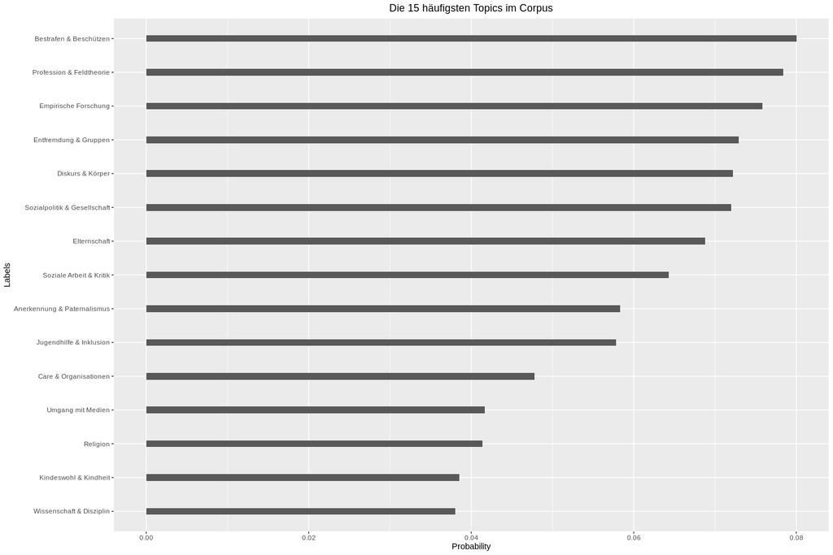

```r
ht
```

```r
#par(bty="n",col="grey40",lwd=3)
#plot.STM(model.stm,type="summary",xlim=(c(0,0.15)), ylim = (c(0,20)), n = 8)
```

## Wordcloud

Als nächstes wurden Wordclouds für die jeweiligen Topics erstellt. Daber wurden die 20 Wörter eines Topics herangezogen, welche die höchste Wahrscheinlichkeit haben, das Topic zu repräsentieren.

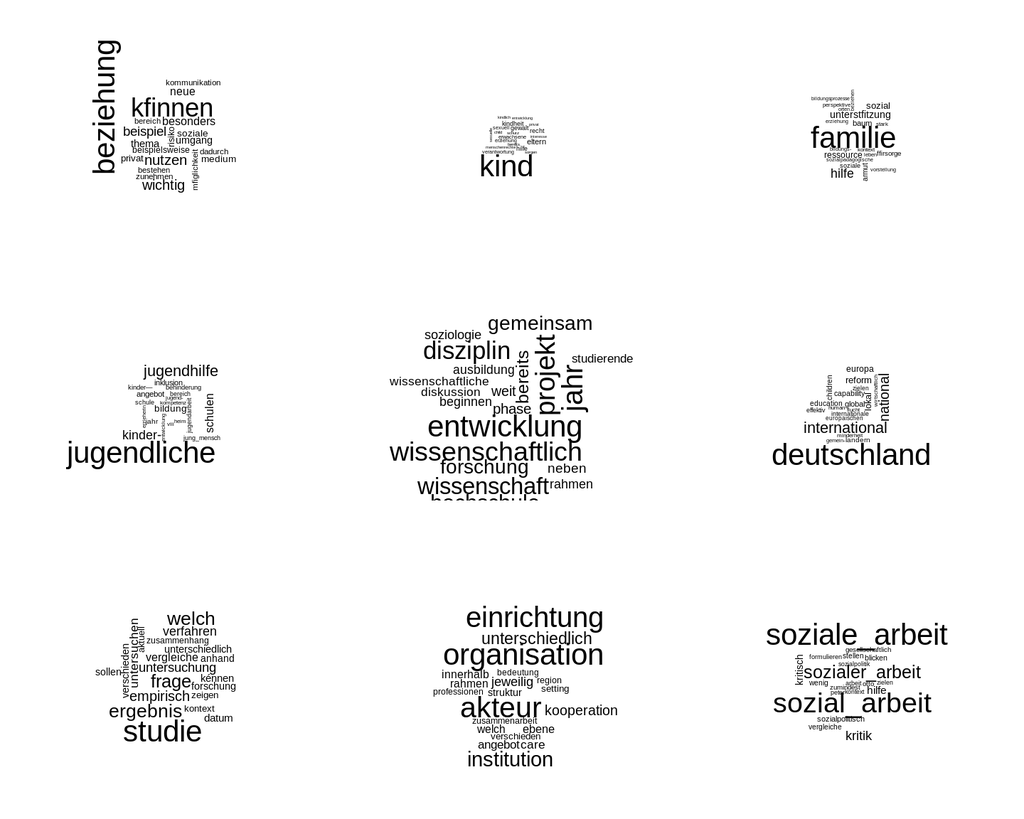

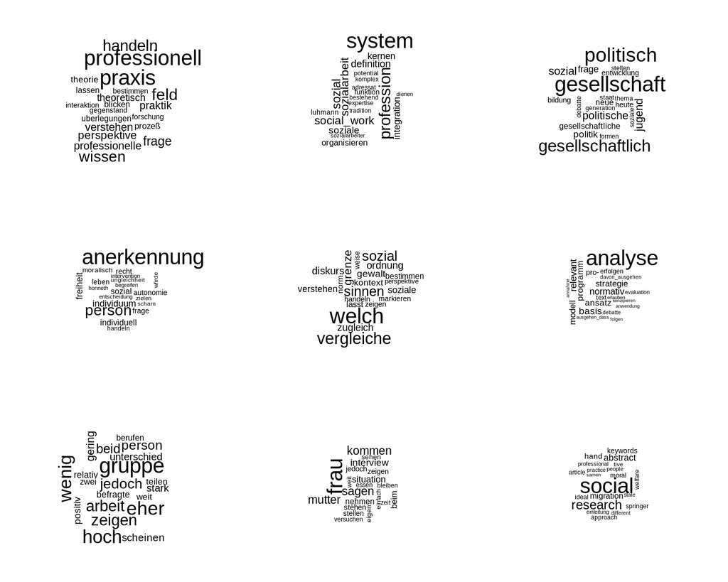

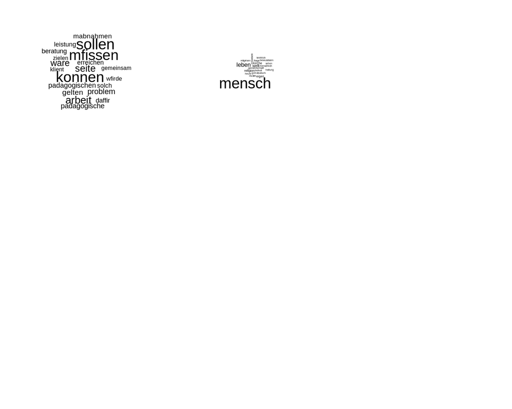

```r
library(RColorBrewer)
library(wordcloud)
topic.count <- 20
par(mfrow=c(3,3))
for (i in seq_along(sample(1:topic.count, size = 20)))
{
  cloud(model.stm, topic = i, scale = c(4,.40),
        max.words = 20, main = paste0("Topic ", model.stm.labels$topicnums[i],  collapse = ", "))
}
```

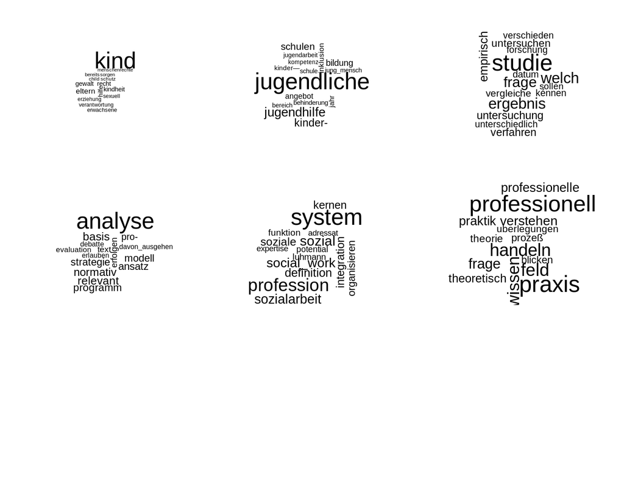

```r
library(RColorBrewer)
library(wordcloud)
topic.count <- c(2,4,7,15,11,10)
par(mfrow=c(3,3))
for (i in topic.count)
{
  cloud(model.stm, topic = i, scale = c(5,.9),
        max.words = 15, main = paste0("Topic ", model.stm.labels$topicnums[i],  collapse = ", "))
}
```

## Topic Diffusion

Als nächstes ist von Interesse, wie sich die einzelnen Topics im Laufe der Zeit entwickelt haben, sprich, wie ihre Diffusion in der Zeitschrift verlief. The model for topical prevalence includes covariates which the analyst believes may influence the frequency with which a topic is discussed. This is specified as a formula which can contain smooth terms using splines or by using the function s. The response portion of the formula should be left blank. See the examples. These variables can include numeric and factor variables. While including variables of class Dates or other non-numeric, non-factor types will work in stm it may not always work for downstream functions such as estimateEffect. Estimates a regression where documents are the units, the outcome is the proportion of each document about a topic in an STM model and the covariates are document-meta data. This procedure incorporates measurement uncertainty from the STM model using the method of composition.

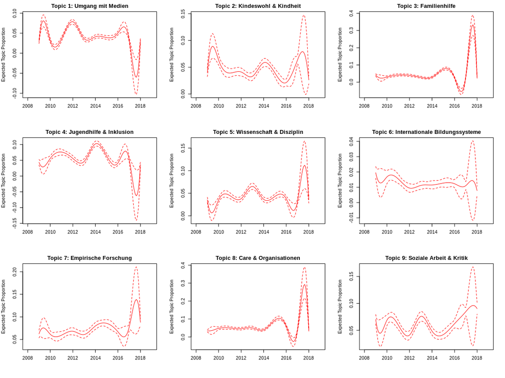

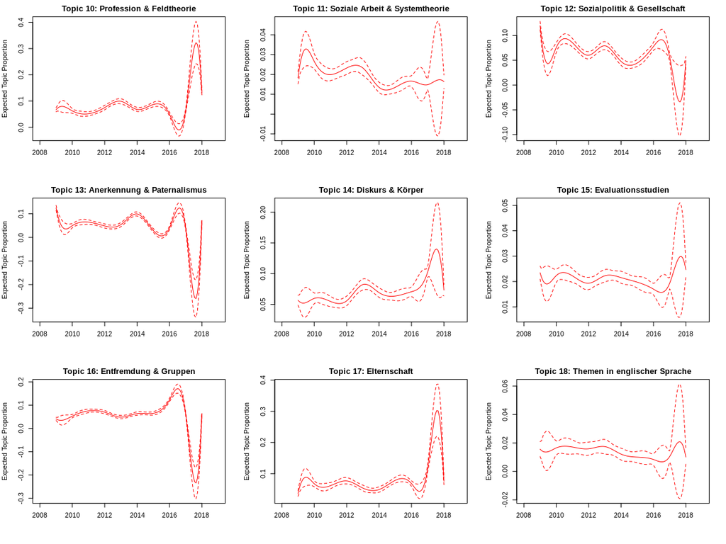

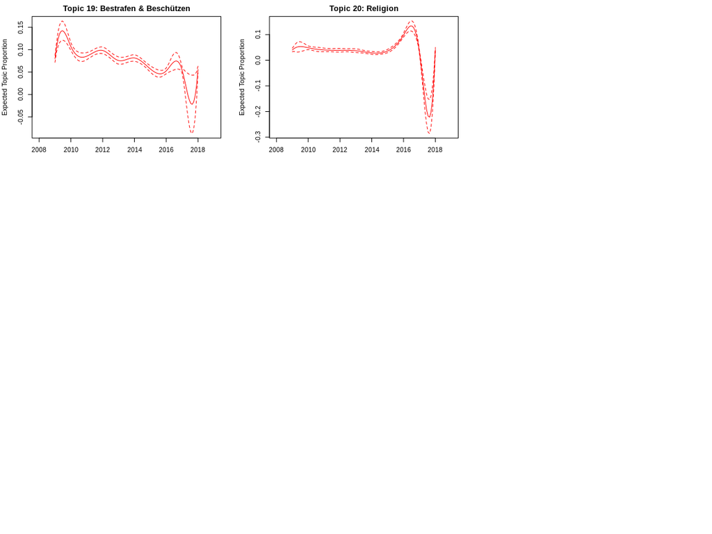

```r
topic.count = 20
model.stm.labels <- labelTopics(model.stm, 1:topic.count)
dfm2stm$meta$datum <- as.numeric(dfm2stm$meta$Jahr)
model.stm.ee <- estimateEffect(1:topic.count ~  s(Jahr), model.stm, meta = dfm2stm$meta)
model.stm.labels$labname <- c("Umgang mit Medien", "Kindeswohl & Kindheit", "Familienhilfe", "Jugendhilfe & Inklusion",
                              "Wissenschaft & Disziplin", "Internationale Bildungssysteme", "Empirische Forschung",
                              "Care & Organisationen", "Soziale Arbeit & Kritik", "Profession & Feldtheorie",
                              "Soziale Arbeit & Systemtheorie", "Sozialpolitik & Gesellschaft", "Anerkennung & Paternalismus",
                              "Diskurs & Körper", "Evaluationsstudien", "Entfremdung & Gruppen", "Elternschaft",
                              "Themen in englischer Sprache", "Bestrafen & Beschützen", "Religion")
par(mfrow=c(3,3))
for (i in seq_along(sample(1:topic.count, size = 20)))
{
  plot(model.stm.ee, "Jahr", method = "continuous", topics = i, main = paste0("Topic ",                              model.stm.labels$topicnums[i], ": ", model.stm.labels$labname[i]), printlegend = F, xlim = c(2008, 2019))
}
```

[figure not shown]

```r
topic.count <- c(2,4,7,15,11,10)
par(mfrow=c(3,3))
for (i in topic.count)
{
  plot(model.stm.ee, "Jahr", method = "continuous", topics = i, main = paste0("Topic ",                              model.stm.labels$topicnums[i], ": ",model.stm.labels$labname[i]), printlegend = F, xlim = c(2008, 2019))
}
```

## Korrelations-Netzwerk

The first method is conceptually simpler and involves a simple thresholding procedure on the estimated marginal topic proportion correlation matrix and requires a human specified threshold. The “simple” method calculates the correlation of the MAP estimates for the topic proportions θ which yields the marginal correlation of the mode of the variational distribution. Then we simply set to 0 those edges where the correlation falls below the threshold.

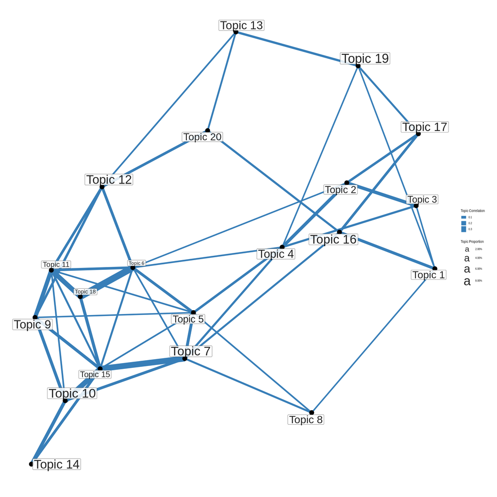

```r
library(stminsights)
library(shiny)
library(shinydashboard)
library(ggraph)
stm_corrs <- get_network(model = model.stm,
                         method = 'simple',
                         labels = paste('Topic', 1:20),
                         cutoff = 0.02,
                         cutiso = TRUE)
graph <-ggraph(stm_corrs, layout = 'fr') +
  geom_edge_link(
    aes(edge_width = weight),
    label_colour = '#fc8d62',
    edge_colour = '#377eb8') +
  geom_node_point(size = 6, colour = 'black')  +
  geom_node_label(
    aes(label = name, size = props),
    colour = 'black',  repel = TRUE, alpha = 0.85) +
  scale_size(range = c(5, 13), labels = scales::percent) +
  labs(size = 'Topic Proportion',  edge_width = 'Topic Correlation') +
  scale_edge_width(range = c(2, 9)) +
  theme_graph()
graph
```

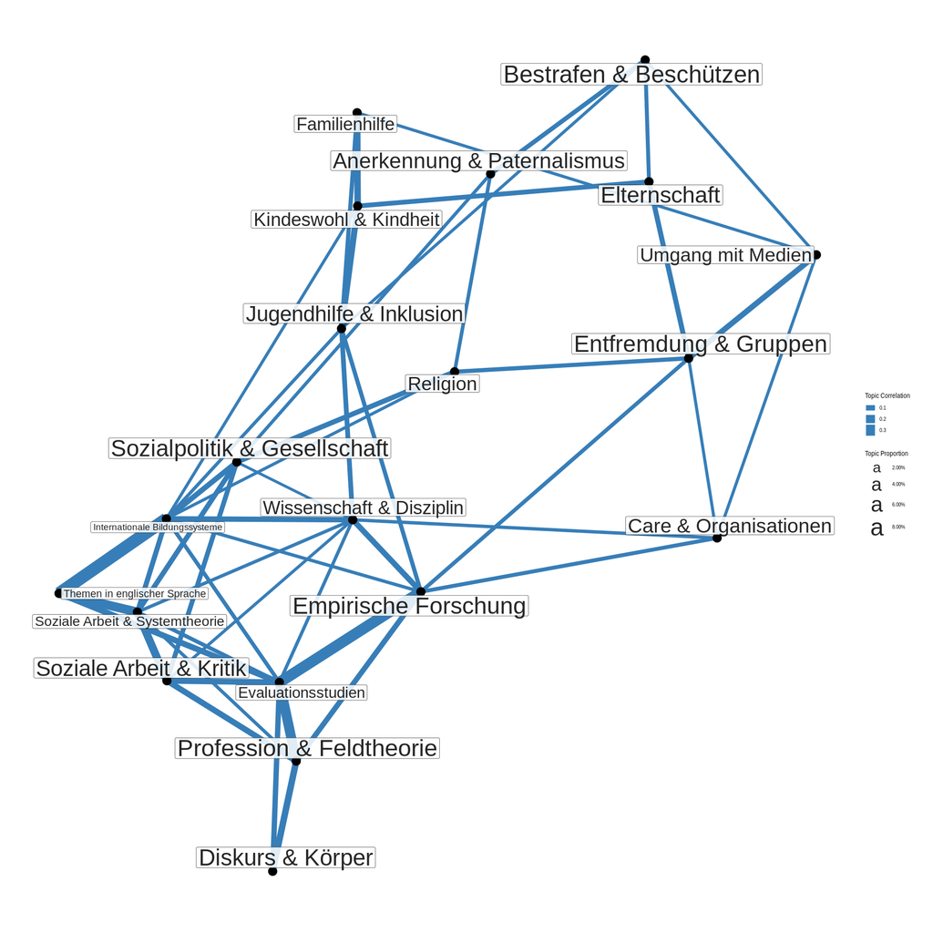

```r
library(stminsights)
library(shiny)
library(shinydashboard)
library(ggraph)
stm_corrs <- get_network(model = model.stm,
                         method = 'simple',
                         labels = paste(model.stm.labels$labname),
                         cutoff = 0.01,
                         cutiso = TRUE)
graph <-ggraph(stm_corrs, layout = 'fr') +
  geom_edge_link(
    aes(edge_width = weight),
    label_colour = '#fc8d62',
    edge_colour = '#377eb8') +
  geom_node_point(size = 6, colour = 'black')  +
  geom_node_label(
    aes(label = name, size = props),
    colour = 'black',  repel = TRUE, alpha = 0.85) +
  scale_size(range = c(5, 13), labels = scales::percent) +
  labs(size = 'Topic Proportion',  edge_width = 'Topic Correlation') +
  scale_edge_width(range = c(2, 9)) +
  theme_graph()
graph
```

```r
library(igraph)
stm_corrs <- get_network(model = model.stm,
                         method = 'simple',
                         labels = paste(model.stm.labels$labname),
                         cutoff = 0.1,
                         cutiso = TRUE)
png("Korrelationsnetzwerk_Topic_Modularity.png", width=900, height=900, res=200)
clp <- cluster_label_prop(stm_corrs)
plot_clp <- plot(clp, stm_corrs,
                 vertex.label.cex = 0.5,
                 vertex.label.color = c("black"),
                 edge.color = rep(c("black")))
plot_clp
```

```r
dev.off()
```

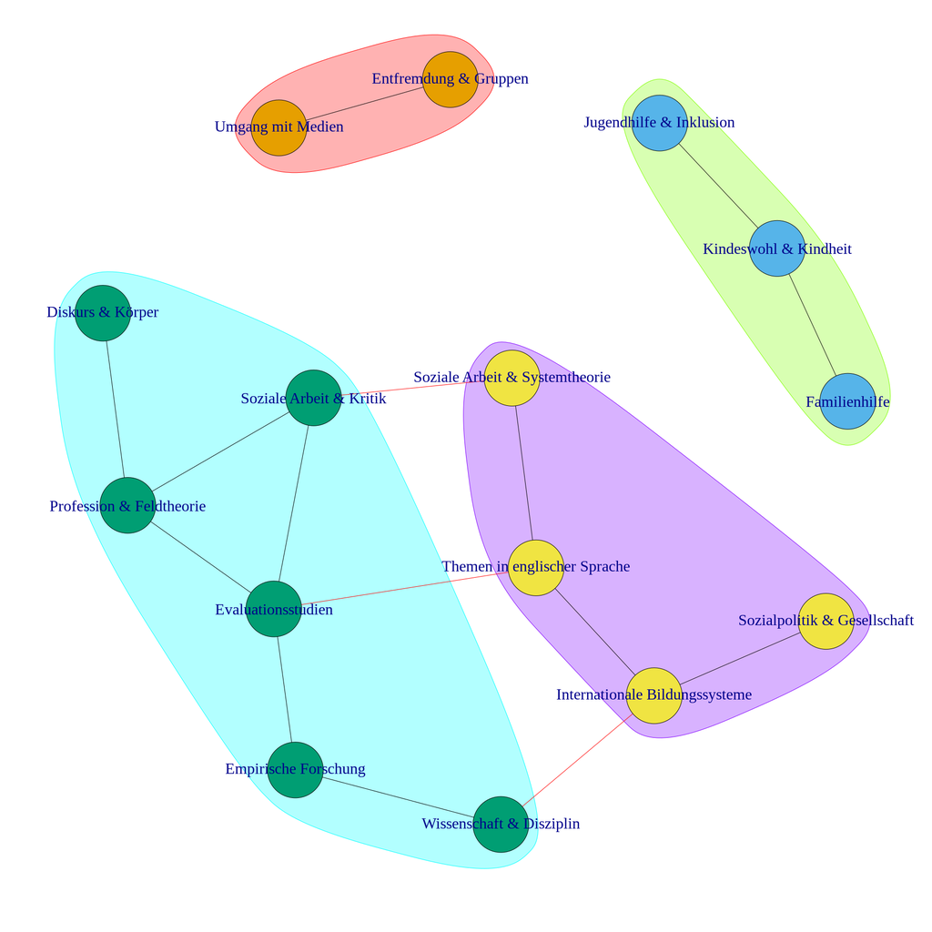

```r
clp <- cluster_label_prop(stm_corrs)
plot_clp <- plot(clp, stm_corrs,
                 vertex.label.cex = 2)
```